# Teste estágio análise de dados

O teste consiste em juntar uma base de dados com nomes de bebês registrados nos Estados Unidos quebrada igualmente em 3 diferentes formatos de arquivos utilizando R ou Python e responder algumas perguntas. O objetivo é avaliar a sua capacidade de extrair dados de diferentes fontes e sua capacidade analítica e de interpretação utilizando as ferramentas disponíveis na linguagem de programação escolhida.

## O dataset

Como citado anteriormente o dataset está quebrado em 3 partes que devem ser juntadas em uma só para a realização das análises. Cada linha representa um nome diferente em um ano específico. **IMPORTANTE: Na parte 3 devem ser filtrados somente os dados que possuem valor 1 na coluna tipo_dado**

- parte1.json
- parte2.csv
- parte3.sqlite: não esquecer de filtrar tipo_dado = 1

### Colunas

| Variável | Class | Descrição |
| --- | --- | --- |
| year | double | Ano de nascimento |
| sex | character | Sexo do bebê |
| name | character | Nome do bebê |
| n | integer | Contagem de bebês |
| prop | double | Proporção do total de nascimentos daquele ano |

## Perguntas

1- Quantos nomes diferentes existem por ano a partir de 2000? Forneça uma tabela e demonstre os resultados graficamente.

2- Qual a média e a mediana da contagem de bebês no dataset. Qual dessas medidas de tendência central você escolheria para descrever esse dado, justifique sua opção.

3- Qual a média e desvio padrão da contagem de bebês no ano de 1997?

4- Levando em conta que o dataset engloba o nascimento de todos os bebês do país imaginário Hilablândia. Qual o total de nascimentos no ano de 2002? Desses, quantos são do sexo feminino e quantos do sexo masculino?

5 (Opcional)- Use sua criatividade para explorar a base e tentar retirar algum insight como por exemplo variação dos nomes Luke e Leia de acordo com lançamento dos filmes da série Star Wars.

6- Envie os côdigos com os resultados por e-mail ou sinta-se a vontade para criar um repositório git (lembre-se de torná-lo público e compartilhar o link!!)

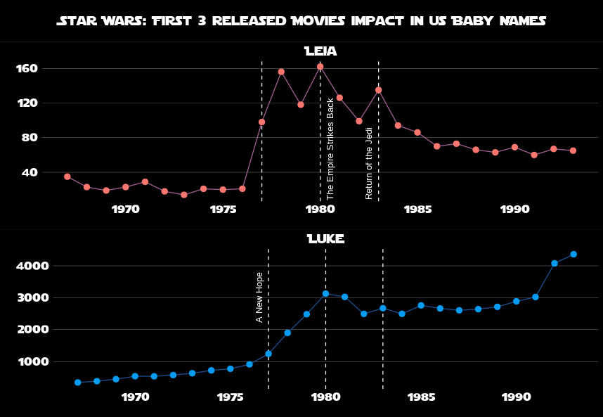